# Visualització de dades

*Alumne: Antoni Espadas Navarro - data: 03/05/23*

## Sanky Diagram

- Descripció: els diagrames Sanky mostren la relació entre diferents variables o categories, i la quantitat de flux que passa entre elles. Són gràfics de xarxes que mostren la direcció del flux i la seva amplada representa la quantitat de flux que hi passa. Els diagrames Sanky són especialment útils per representar dades sobre la relació entre diferents categories i el flux que hi passa, i poden ser utilitzats per a qualsevol variable o categoria.
- Exemples d'aplicació: tràfic web (visites a les pàgines web), contaminacions de països, etc.
- Tipus de dades: aquesta tècnica és adequada per a dades quantitatives i també pot ser utilitzada per a dades categòriques, ja que mostra la relació entre categories.
- Limitacions: els diagrames Sanky són adequats per a conjunts de dades mitjans o grans, ja que si la quantitat de dades és petita, el diagrama pot resultar poc informatiu o difícil de llegir.

```python
import pandas as pd
import plotly.graph_objects as go
```

```python
# seleccionem i filtrem les variables que ens interessa graficar
df = pd.read_csv('Methane_final.csv', encoding = "UTF-8")
df = df[['region', 'type', 'emissions', 'baseYear']]
df = df.groupby(['region', 'type', 'baseYear'], as_index=False).sum()
categorias = df['region'].unique().tolist() + df['type'].unique().tolist() + df['baseYear'].unique().tolist()

# crear conexions entre les categoríes anteriors seleccionades
conexiones = []
for i in df.index:
    conexion = {
        'source': categorias.index(df['region'][i]),
        'target': categorias.index(df['type'][i]),
        'value': df['emissions'][i],
        'baseYear': df['baseYear'][i]
    }
    conexiones.append(conexion)

# crearem un DataFrame per les categorías i l'altre per a les conexions
df_cat = pd.DataFrame(categorias)
df_cat.columns = ['categoria']
df_con = pd.DataFrame(conexiones)

# Montem la figura del diagrama
fig = go.Figure(data=[go.Sankey(
    node = dict(
        pad = 15,
        thickness = 20,
        line = dict(color = "black", width = 0.5),
        label = df_cat['categoria'].tolist(),
    ),
    link = dict( # customitzem els labels dels fluxos
        source = df_con['source'].tolist(),
        target = df_con['target'].tolist(),
        value = df_con['value'].tolist(),
        label = df_con['value'].tolist(),
        customdata = df_con['baseYear'].tolist(),
        hovertemplate = 'De: %{source.label}<br>A: %{target.label}<br>Value: %{value}<br>Any: %{customdata}'
    ))])

# la distribució de les emissions de CO2 per sector i regió
fig.update_layout(title="Distribució de les emissions de Metà (CH) per sector i regió, classificat per any (2019-2022) d'emissió",
                  font=dict(size=12, color='black'),
                  height=800, width=1000)
# Subtitle de la font
fig.add_annotation(
    xref="paper",
    yref="paper",
    x=0.005,
    y=-0.05,
    text="Font: Kaggle - Dataset - Global Methane Emissions",
    showarrow=False,
    font=dict(size=12),
)
fig.show(renderer='notebook')
```

[interactive chart not shown]

Font: https://www.kaggle.com/datasets/ashishraut64/global-methane-emissions?resource=download

## Waterfall Chart

- Descripció: els gràfics de cascada mostren la distribució dels valors d'una variable a través del temps o de diferents fases d'un procés. El gràfic comença amb un valor inicial, que es representa per una barra, i després es mostren les diferents fases o factors que van afectant aquest valor, tant positius com negatius. Els valors s'apilen uns damunt dels altres, formant una estructura similar a la de les cascades. Aquest tipus de gràfic és ideal per a la comparació entre diferents fases o períodes.
- Exemples d'aplicació: finances (ingressos i despeses en diferents fases), rendiment d'una empresa (anàlisi de beneficis i pèrdues), etc.
- Tipus de dades: és adequada per a dades quantitatives i també pot ser utilitzada per a dades categòriques, ja que mostra la distribució dels valors.
- Limitacions: els gràfics de cascada són adequats per a conjunts de dades mitjans o grans, ja que si la quantitat de dades és petita, el gràfic pot resultar poc informatiu o difícil de llegir.

```python
 # Carreguem el dataset
df = pd.read_csv('2021_od10_resultat-ingressos-despeses-sec.csv', encoding='UTF-8')

# Agruparem les dades per tipologia d'operacions i mostrarem el seu import
df = df.groupby('Tipologia_operacions', as_index=False).sum()
imports = df['Imports_Milions€'].tolist()
operacions = df['Tipologia_operacions'].tolist()

# Crearem el gràfic
fig = go.Figure(go.Waterfall(
    name = "Ingressos i despeses",
    orientation = "v",
    measure = ["relative", "relative", "relative", "total", "relative"],
    x = operacions,
    textposition = "outside",
    text = imports,
    y = imports,
    connector = {"line":{"color":"rgb(63, 63, 63)"}},
))

fig.update_layout(
    title = "Evolució dels ingressos i despeses per diferents tipologies d'operacions de l'any 2000 fins 2022 - Aj.Barcelona",
    showlegend = False,
    height=800
)

# Subtitle font
fig.add_annotation(
    xref="paper",
    yref="paper",
    x=0.0005,
    y=-0.3,
    text="Font: Ajuntament de Barcelona - Open Data - Evolution of the result, revenues and expenditures of the budget of Barcelona City Council",
    showarrow=False,
    font=dict(size=11),
)
fig.show(renderer='notebook')
```

[interactive chart not shown]

Font: https://opendata-ajuntament.barcelona.cat/data/en/dataset/evolucio-resultat-ingressos-i-despeses/resource/69fa83f5-b174-4226-96c6-ff65984a997e

**Valoració:**

1. El gràfic Waterfall Chart que representi l'evolució del resultat, ingressos i despeses del pressupost de l'Ajuntament de Barcelona (des de l'any 2000 fins 2022).
2. Cada barra vertical del gràfic representaria una tipologia d'operació, i les barres mostrarien les quantitats de diners ingressats o gastats per aquesta tipologia.
3. Les barres que pugen representarien els ingressos i les que baixen les despeses. La suma de totes les barres d'ingressos i despeses per a un any donat donaria el balanç total des del 2000 fins 2022. El balanç final ha sigut positiu (l'ajuntament de Barcelona capacitat finançera)

## Rain cloud Plots

- Descripció: els gràfics de núvol de pluja mostren la distribució de les dades a través de diferents grups o categories. Aquesta tècnica combina les funcionalitats dels boxplots, les densities plots i les dot plots. Els núvols de pluja mostren les dades en forma de núvol, on la seva densitat representa la freqüència relativa de les dades. A més a més, també mostren les dades en forma de boxplots, que mostren la mediana, quartils i els valors mínim i màxim, i en forma de dot plots, que mostren cada valor individual. Això fa que els núvols de pluja siguin una eina útil per mostrar la distribució de les dades d'una forma completa i clara.
- Exemples d'aplicació: al camp de la psicologia (anàlisi de dades de conductes o emocions), medicina (anàlisi de dades clíniques), etc.
- Tipus de dades: és adequada per a dades quantitatives, ja que mostra la distribució de les dades. També pot ser utilitzada per a dades categòriques, però en aquest cas, les dades s'han de transformar en valors numèrics per poder ser representades.
- Limitacions: els núvols de pluja són adequats per a conjunts de dades mitjans o grans, ja que si la quantitat de dades és petita, el gràfic pot resultar poc informatiu o difícil de llegir. També pot ser difícil interpretar els núvols de pluja si les distribucions de les dades són molt diferents entre els grups o categories.

```python
%load_ext rpy2.ipython
```

```
Defaulting to continuous.
```

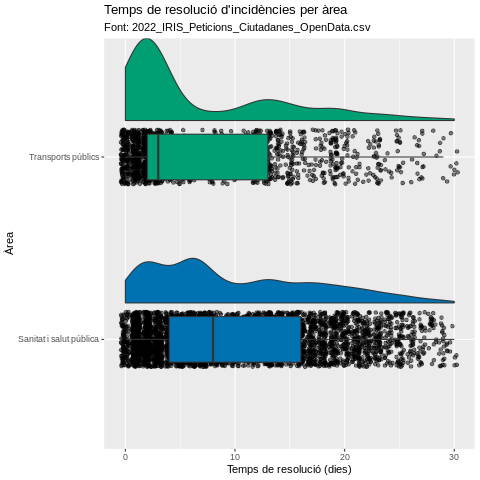

```python
%%R
library(dplyr)
library(data.table)
library(ggplot2)
library(PupillometryR)

dades <- read.csv("2022_IRIS_Peticions_Ciutadanes_OpenData.csv", encoding = "UTF-8")
dades <- dades %>% filter(TIPUS  %in% c("INCIDENCIA") & AREA %in% c("Sanitat i salut pública", "Transports públics"))

# Crear variables de temps de resolució per cada incidència
dades$DIA_DATA_ALTA <- as.Date(dades$DIA_DATA_ALTA, format = "%d/%m/%Y")
dades$DIA_DATA_TANCAMENT <- as.Date(dades$DIA_DATA_TANCAMENT, format = "%d/%m/%Y")
dades$TEMPS_RESOLUCIO <- abs(difftime(dades$DIA_DATA_TANCAMENT, dades$DIA_DATA_ALTA, units = "days"))


# generem el plot Rainy Cloud
ggplot(dades, aes(y = TEMPS_RESOLUCIO, x = AREA, fill = AREA)) +
    geom_flat_violin(position = position_nudge(x = .2, y = 0)) +
    coord_flip() +
    geom_jitter(alpha = 0.5,width = 0.15) +
    theme(legend.position = "none") +
    geom_boxplot( width = .25,  outlier.shape = NA ) +
    labs(title = "Temps de resolució d'incidències per àrea",
         y = "Temps de resolució (dies)",
         x = "Àrea",
         subtitle = "Font: 2022_IRIS_Peticions_Ciutadanes_OpenData.csv") +
    scale_fill_manual(values = c("Sanitat i salut pública" = "#0072B2", "Transports públics" = "#009E73"))
```

Font: https://opendata-ajuntament.barcelona.cat/data/ca/dataset/iris/resource/3224123d-488e-4e03-9b64-ed278a9c3c79